# Analisis Faktor yang Mempengaruhi Revenue Rental Film pada Database Sakila

Gamma Dekan Wicaksono - M0724043

2026-05-26

##import library

```r
library(DBI)
library(RMySQL)
library(dplyr)
library(ggplot2)
library(knitr)
library(corrplot)
```

##connection

```r
con <- dbConnect(
  RMySQL::MySQL(),
  dbname = "sakila",
  host = "localhost",
  user = "root",
  password = "gammaadek123"
)
```

##select data

```r
query <- "
SELECT
    f.film_id,
    f.title,
    c.name AS category,
    f.length,
    f.rental_duration,
    f.rental_rate,
    f.replacement_cost,
    COUNT(r.rental_id) AS rental_count,
    SUM(p.amount) AS revenue
FROM film f
JOIN inventory i
    ON f.film_id = i.film_id
JOIN rental r
    ON i.inventory_id = r.inventory_id
JOIN payment p
    ON r.rental_id = p.rental_id
JOIN film_category fc
    ON f.film_id = fc.film_id
JOIN category c
    ON fc.category_id = c.category_id
GROUP BY
    f.film_id,
    f.title,
    c.name,
    f.length,
    f.rental_duration,
    f.rental_rate,
    f.replacement_cost
ORDER BY revenue DESC
"

data <- dbGetQuery(con, query)

head(data)
```

```
##   film_id             title    category length rental_duration rental_rate
## 1     879  TELEGRAPH VOYAGE       Music    148               3        4.99
## 2     973         WIFE TURN Documentary    183               3        4.99
## 3    1000         ZORRO ARK      Comedy     50               3        4.99
## 4     369 GOODFELLAS SALUTE      Sci-Fi     56               4        4.99
## 5     764    SATURDAY LAMBS      Sports    150               3        4.99
## 6     893       TITANS JERK      Sci-Fi     91               4        4.99
##   replacement_cost rental_count revenue
## 1            20.99           27  231.73
## 2            27.99           31  223.69
## 3            18.99           31  214.69
## 4            22.99           31  209.69
## 5            28.99           28  204.72
## 6            11.99           29  201.71
```

##deskripsi data

```r
str(data)
```

```
## 'data.frame':    958 obs. of  9 variables:
##  $ film_id         : num  879 973 1000 369 764 893 897 403 460 444 ...
##  $ title           : chr  "TELEGRAPH VOYAGE" "WIFE TURN" "ZORRO ARK" "GOODFELLAS SALUTE" ...
##  $ category        : chr  "Music" "Documentary" "Comedy" "Sci-Fi" ...
##  $ length          : num  148 183 50 56 150 91 179 121 178 83 ...
##  $ rental_duration : num  3 3 3 4 3 4 3 5 3 3 ...
##  $ rental_rate     : num  4.99 4.99 4.99 4.99 4.99 4.99 4.99 4.99 4.99 4.99 ...
##  $ replacement_cost: num  21 28 19 23 29 ...
##  $ rental_count    : num  27 31 31 31 28 29 27 30 26 22 ...
##  $ revenue         : num  232 224 215 210 205 ...
```

```r
summary(data)
```

```
##     film_id          title             category             length
##  Min.   :   1.0   Length:958         Length:958         Min.   : 46.00
##  1st Qu.: 256.2   Class :character   Class :character   1st Qu.: 80.25
##  Median : 504.5   Mode  :character   Mode  :character   Median :114.00
##  Mean   : 502.6                                         Mean   :115.49
##  3rd Qu.: 751.8                                         3rd Qu.:150.00
##  Max.   :1000.0                                         Max.   :185.00
##  rental_duration  rental_rate    replacement_cost  rental_count
##  Min.   :3.00    Min.   :0.990   Min.   : 9.99    Min.   : 4.00
##  1st Qu.:4.00    1st Qu.:0.990   1st Qu.:14.99    1st Qu.:11.00
##  Median :5.00    Median :2.990   Median :19.99    Median :16.00
##  Mean   :4.97    Mean   :2.977   Mean   :20.06    Mean   :16.75
##  3rd Qu.:6.00    3rd Qu.:4.990   3rd Qu.:24.99    3rd Qu.:22.00
##  Max.   :7.00    Max.   :4.990   Max.   :29.99    Max.   :34.00
##     revenue
##  Min.   :  5.94
##  1st Qu.: 37.74
##  Median : 62.32
##  Mean   : 70.36
##  3rd Qu.: 95.75
##  Max.   :231.73
```

- Revenue tiap film cukup bervariasi, ada film populer dan menghasilkan revenue cukup tinggi
- Rata rata rental film sekitar 16-17 kali
- Durasi film rata-rata sekitar 115 menit

##top 10 film dengan revenue tertinggi

```r
top10 <- data %>%
  arrange(desc(revenue)) %>%
  head(10)

kable(top10)
```

| film_id | title | category | length | rental_duration | rental_rate | replacement_cost | rental_count | revenue |
| --- | --- | --- | --- | --- | --- | --- | --- | --- |
| 879 | TELEGRAPH VOYAGE | Music | 148 | 3 | 4.99 | 20.99 | 27 | 231.73 |
| 973 | WIFE TURN | Documentary | 183 | 3 | 4.99 | 27.99 | 31 | 223.69 |
| 1000 | ZORRO ARK | Comedy | 50 | 3 | 4.99 | 18.99 | 31 | 214.69 |
| 369 | GOODFELLAS SALUTE | Sci-Fi | 56 | 4 | 4.99 | 22.99 | 31 | 209.69 |
| 764 | SATURDAY LAMBS | Sports | 150 | 3 | 4.99 | 28.99 | 28 | 204.72 |
| 893 | TITANS JERK | Sci-Fi | 91 | 4 | 4.99 | 11.99 | 29 | 201.71 |
| 897 | TORQUE BOUND | Drama | 179 | 3 | 4.99 | 27.99 | 27 | 198.72 |
| 403 | HARRY IDAHO | Drama | 121 | 5 | 4.99 | 18.99 | 30 | 195.70 |
| 460 | INNOCENT USUAL | Foreign | 178 | 3 | 4.99 | 26.99 | 26 | 191.74 |
| 444 | HUSTLER PARTY | Comedy | 83 | 3 | 4.99 | 22.99 | 22 | 190.78 |

- Telegraph Voyage menjadi film dengan Revenue paling besar dengan revenue sebesar 231.73 diikuti oleh Wife Turn yang memperoleh revenue sebesar 223.69

dua film diatas dianggap sebagai film paling profitable dan asset penting dalam bisnis rental ini

##visualisai revenue per kategori

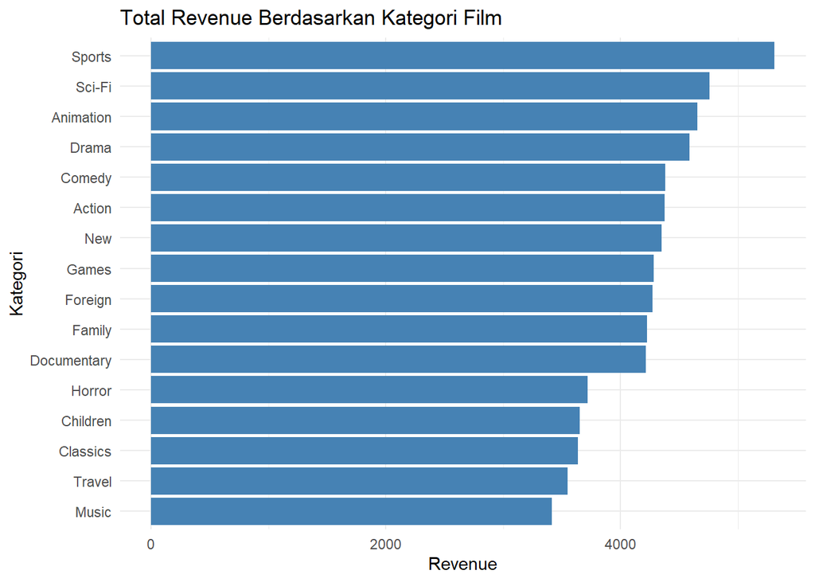

```r
kategori_rev <- data %>%
  group_by(category) %>%
  summarise(total_revenue = sum(revenue)) %>%
  arrange(desc(total_revenue))

ggplot(kategori_rev,
       aes(x = reorder(category, total_revenue),
           y = total_revenue)) +
  geom_bar(stat = "identity", fill = "steelblue") +
  coord_flip() +
  labs(
    title = "Total Revenue Berdasarkan Kategori Film",
    x = "Kategori",
    y = "Revenue"
  ) +
  theme_minimal()
```

-Kategori Film mempengaruhi pendapatan rental, hal ini berpotensi dijadikan strategi bisnis untuk memperoleh revenue yang lebih tinggi

##Visualisasi Rental Count vs Revenue

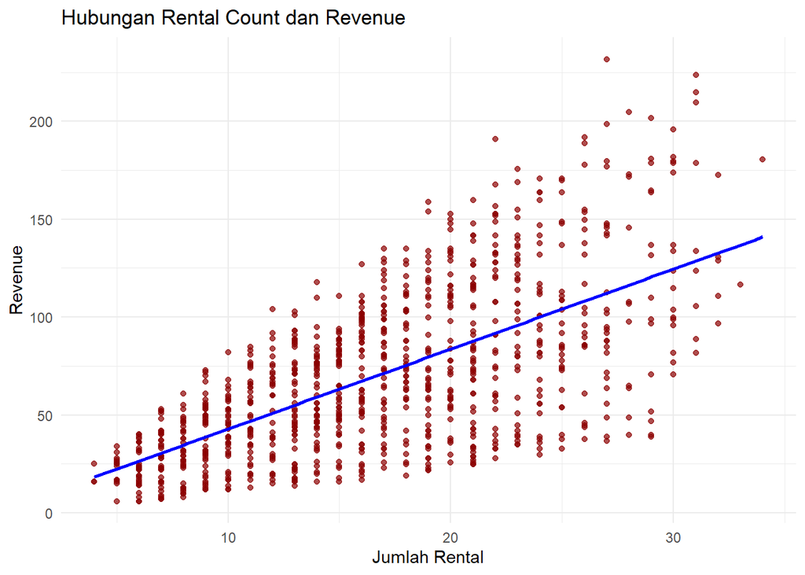

```r
ggplot(data,
       aes(x = rental_count,
           y = revenue)) +
  geom_point(color = "darkred", alpha = 0.7) +
  geom_smooth(method = "lm", se = FALSE, color = "blue") +
  labs(
    title = "Hubungan Rental Count dan Revenue",
    x = "Jumlah Rental",
    y = "Revenue"
  ) +
  theme_minimal()
```

- Ada Hubungan Linear Positif antara jumlah rental dan revenue , film yang sering dirental cenderung menghasilkan pendapatan tinggi.

##Korelasi Antar Variabel

```r
numeric_data <- data %>%
  select(length,
         rental_duration,
         rental_rate,
         replacement_cost,
         rental_count,
         revenue)

cor_matrix <- cor(numeric_data)

cor_matrix
```

```
##                        length rental_duration rental_rate replacement_cost
## length            1.000000000     0.054994908  0.03629512      0.008444920
## rental_duration   0.054994908     1.000000000  0.03055737     -0.002324065
## rental_rate       0.036295117     0.030557366  1.00000000     -0.048184083
## replacement_cost  0.008444920    -0.002324065 -0.04818408      1.000000000
## rental_count     -0.032234920    -0.061081887 -0.05324983      0.064438530
## revenue          -0.004042052    -0.295395120  0.60832496      0.017621994
##                  rental_count      revenue
## length            -0.03223492 -0.004042052
## rental_duration   -0.06108189 -0.295395120
## rental_rate       -0.05324983  0.608324956
## replacement_cost   0.06443853  0.017621994
## rental_count       1.00000000  0.645378160
## revenue            0.64537816  1.000000000
```

##Heatmap Korelasi

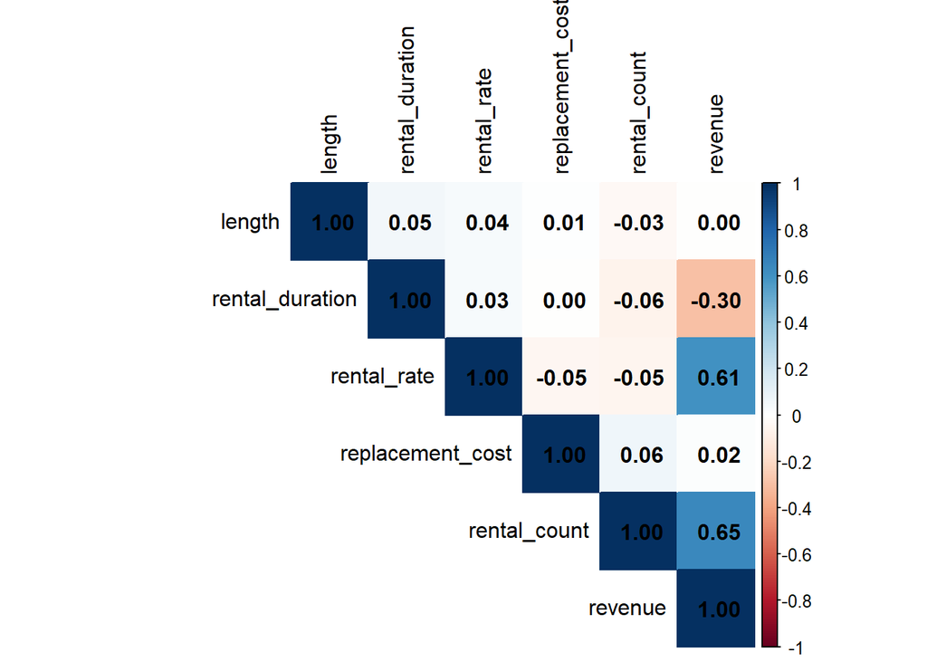

```r
corrplot(
  cor_matrix,
  method = "color",
  type = "upper",
  tl.col = "black",
  addCoef.col = "black"
)
```

- Diperkuat dalam heatmap ada hubungan positif kuat antara revenue dan rental count
- harga rental juga berpengaruh besar terhadap revenue.
- semakin lama masa rental,revenue cenderung menurun.Kemungkinan, film dengan durasi rental pendek lebih cepat diputar ulang.

-Faktor paling berpengaruh terhadap revenue:

1.rental_count 2.rental_rate

Sedangkan:

1.panjang film, 2.replacement_cost

tidak terlalu berpengaruh.

##Model Regresi Linear

```r
model <- lm(
  revenue ~ rental_count +
    length +
    rental_duration +
    rental_rate +
    replacement_cost,
  data = data
)

summary(model)
```

```
##
## Call:
## lm(formula = revenue ~ rental_count + length + rental_duration +
##     rental_rate + replacement_cost, data = data)
##
## Residuals:
##     Min      1Q  Median      3Q     Max
## -41.775  -8.488   0.028   8.442  67.901
##
## Coefficients:
##                    Estimate Std. Error t value Pr(>|t|)
## (Intercept)      -10.696185   2.716287  -3.938 8.82e-05 ***
## rental_count       4.201022   0.063283  66.385  < 2e-16 ***
## length             0.009157   0.010408   0.880    0.379
## rental_duration   -8.270454   0.299579 -27.607  < 2e-16 ***
## rental_rate       16.780607   0.256571  65.403  < 2e-16 ***
## replacement_cost   0.038999   0.069554   0.561    0.575
## ---
## Signif. codes:  0 '***' 0.001 '**' 0.01 '*' 0.05 '.' 0.1 ' ' 1
##
## Residual standard error: 13 on 952 degrees of freedom
## Multiple R-squared:  0.906,  Adjusted R-squared:  0.9055
## F-statistic:  1836 on 5 and 952 DF,  p-value: < 2.2e-16
```

## Persamaan Regresi

$$Y = \beta_0 + \beta_1X_1 + \beta_2X_2 + \beta_3X_3 + \beta_4X_4 +
\beta_5X_5 + \epsilon$$
Y = Revenue β0 = Intercept β1,β2,… = Koefisien regresi X1 = Rental Count X2 = Length X3 = Rental Duration X4 = Rental Rate X5 = Replacement Cost ϵ = Error

- Revenue diprediksi menggunakan:

jumlah rental, durasi film, rental duration, rental rate, replacement cost.

##Interpretasi Model

```r
coef(model)
```

```
##      (Intercept)     rental_count           length  rental_duration
##    -10.696184665      4.201021820      0.009157091     -8.270453936
##      rental_rate replacement_cost
##     16.780606713      0.038999160
```

$$\hat{Revenue} =
-10.696
+ 4.201(\text{rental\_count})
+ 0.009(\text{length})
- 8.270(\text{rental\_duration})
+ 16.781(\text{rental\_rate})
+ 0.039(\text{replacement\_cost})$$

- Rental count setiap tambahan 1 rental, revenue naik sekitar 4.201022
- Rental Rate Setiap tambahan 1 Harga rental, revenue naik sekitar 16.78

-Rental duration semakin lama masa rental, revenue justru turun -8.27

- Multiple R-squared: 0.906 Artinya model mampu menjelaskan sekitar 90.6% variasi revenue.

##Prediksi Revenue

```r
data$predicted_revenue <- predict(model)

head(data)
```

```
##   film_id             title    category length rental_duration rental_rate
## 1     879  TELEGRAPH VOYAGE       Music    148               3        4.99
## 2     973         WIFE TURN Documentary    183               3        4.99
## 3    1000         ZORRO ARK      Comedy     50               3        4.99
## 4     369 GOODFELLAS SALUTE      Sci-Fi     56               4        4.99
## 5     764    SATURDAY LAMBS      Sports    150               3        4.99
## 6     893       TITANS JERK      Sci-Fi     91               4        4.99
##   replacement_cost rental_count revenue predicted_revenue
## 1            20.99           27  231.73          163.8291
## 2            27.99           31  223.69          181.2267
## 3            18.99           31  214.69          179.6578
## 4            22.99           31  209.69          171.5983
## 5            28.99           28  204.72          168.3604
## 6            11.99           29  201.71          163.0878
```

##Visualisasi Actual vs Predicted

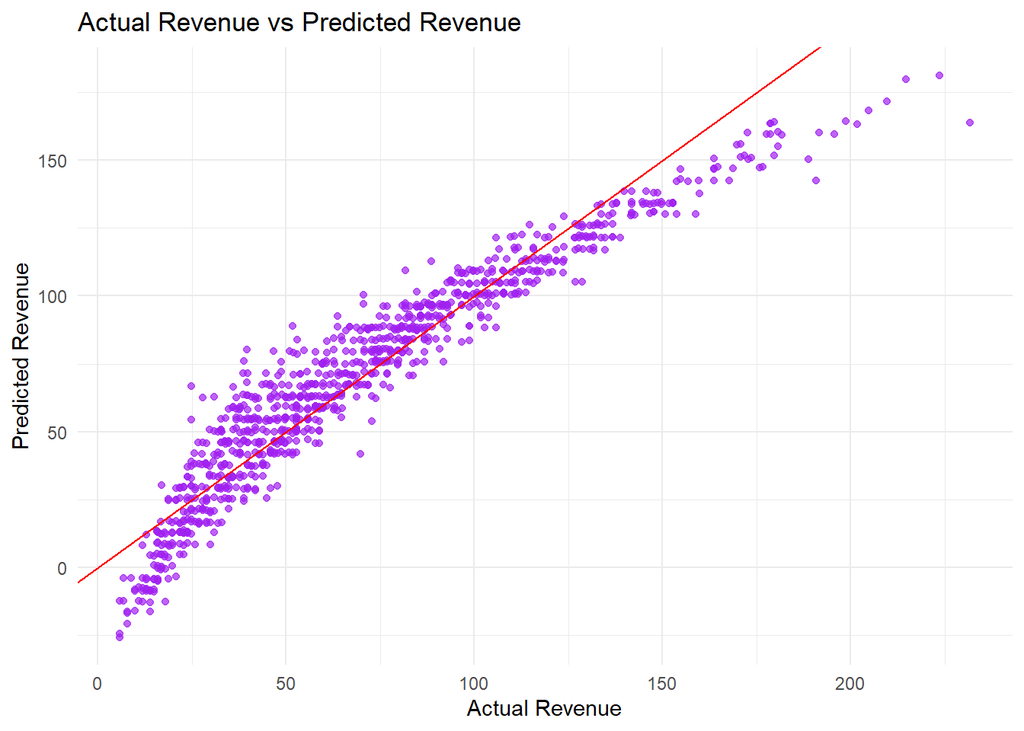

```r
ggplot(data,
       aes(x = revenue,
           y = predicted_revenue)) +
  geom_point(color = "purple", alpha = 0.7) +
  geom_abline(slope = 1,
              intercept = 0,
              color = "red") +
  labs(
    title = "Actual Revenue vs Predicted Revenue",
    x = "Actual Revenue",
    y = "Predicted Revenue"
  ) +
  theme_minimal()
```

- Ini mengecek seberapa bagus model prediksi.

Yang terlihat

Titik-titik dekat garis merah.

Artinya:

hasil prediksi mendekati data asli, model regresi bekerja dengan baik.

## KESIMPULAN

Berdasarkan hasil analisis terhadap database Sakila, diketahui bahwa revenue rental film dipengaruhi oleh beberapa faktor utama, terutama jumlah rental dan harga rental.

Hasil visualisasi menunjukkan bahwa kategori Sports dan Sci-Fi merupakan kategori dengan revenue tertinggi. Selain itu, analisis korelasi dan regresi menunjukkan bahwa rental_count memiliki hubungan positif paling kuat terhadap revenue.

Model regresi linear menghasilkan nilai R-Squared sebesar 0.906 yang menunjukkan bahwa model mampu menjelaskan sekitar 90.6% variasi revenue. Hal ini menunjukkan bahwa model yang dibangun memiliki performa yang sangat baik.

Secara keseluruhan, jumlah rental dan rental_rate merupakan faktor paling signifikan dalam meningkatkan pendapatan rental film pada database Sakila.